# SoleMon data handling handbook version 2024

2024-10-24

# Access file creation and structure

## Starting a new access file

Data collected onboard are stored in access files, located in the “OnBoard/access” subfolder. Ideally, a maximum of 20 hauls should be stored in a .accdb file. **IMPORTANT: in case the data collection is done in parallel over multiple laptops, the “OnBoard” folder must be renamed with unique identifiers (e.g.: OnBoard_2024_PLE). Instructions to set up a folder on a new laptop are reported in the repository main page**

To start a new file, copy the template version, which in 2024 it is called “bio_data_v2024_SOLEMON_template.accdb”, paste it in the same “OnBoard/access” (or OnBoard_2024_PLE/access) subfolder and rename it as “bio_data_v2024_SOLEMON_YEAR_N.accdb”, where YEAR is the reporting year and N is a progressive number. Example: “**bio_data_v2024_SOLEMON_2024_1.accdb**” . *It does not matter if parts of the same haul are in different files, this is handled in post-processing. It does not matters if access with the same name are located in different laptops, this is handled in post processing*.

## Starting a new haul

Each access file contains a template sheet, called “cala_template”. To start a new haul, copy the template sheet, paste it and rename it as “cala_x”, where *x* is the haul number. Example: **cala_1**; cala_7bis. *It does not matter if parts of the same haul are in different files, this is handled in post-processing*.

### Haul sheet Structure

[figure not shown]

Figure 2: Example of the structure of the access file

### .accdb auto compilation general details

Auto compilation applies to some column of the access file. This mean that in the processing of the table, to empty cells is assigned the first available data that is found in the previous rows. When collecting data, for these column you need to specify the value just for the first observation, then you should fill the value again only when this change. These columns are:

- **gear**
- **species_name**
- **sex** (only for crustaceans)

# Collecting data

## Standard procedure

Standard procedure applies when all the individuals for a given species are collected and reported

### Target species

When reporting data for target species you should use only the first 7 columns. Of these, the columns *gear* and *species_name* autocompiles according to the first record inserted. This mean that you should write in these columns only the first time you report an observation (i.e.: first record of a gear, first record of a species). The column *id_specimen* serves to store any kind of individual id (e.g.: otholits code, genetic samples).

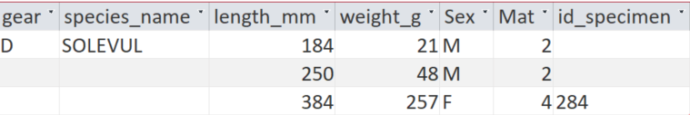

Figure 3: example of compilation for target species species

### Elasmobranchs

When reporting data for elasmobranchs you should use only the first 9 columns. Of these, the columns *gear* and *species_name* autocompiles according to the first record inserted. This mean that you should write in these columns only the first time you report an observation (i.e.: first record of a gear, first record of a species). The column *id_specimen* serves to store any kind of individual id (e.g.: otholits code, genetic samples). Refer to the Figure 4 for reporting the 3 length measures

[figure not shown]

Figure 4: example of compilation for elasmobranchs species

### Other commercial species

When reporting data for other commercial species you should use only the first 4 columns. Of these, the columns *gear* and *species_name* autocompiles according to the first record inserted. This mean that you should write in these columns only the first time you report an observation (i.e.: first record of a gear, first record of a species).

For this species category are recorded individual length and cumulative weight. The cumulative weight should be reported in the last record, as in Figure 5.

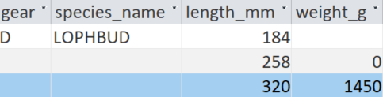

Figure 5: example of compilation for other commercial species

### Shellfishes (when all the individuals are sampled)

When reporting data for shellfishes (MUREBRA, HEXATRU, OSTREDU) you should use the columns as reported in Figure 6. Of these, the columns *gear* and *species_name* autocompiles according to the first record inserted. This mean that you should write in these columns only the first time you report an observation (i.e.: first record of a gear, first record of a species).

NB: in case of subsamples, refer to the dedicated section

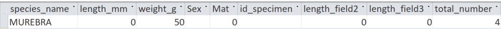

Figure 6: example of compilation for shellfishes species

## Subsamples

In terms of onboard procedure, the cases general refers to:

- Case 1 (C1): ALL the individuals from a haul are collected (sorted sample), then the sorted sample is subsampled and processed
- Case 2 (C2): an unsorted subsample is taken from the haul, then it is sorted and ALL the individuals from the sorted subsample are processed
- Case 3 (C3): a partially sorted subsample (e.g.: the subsample is taken after commercial species are sorted out, same procedure used for the discard subsample) is taken from the haul, then it is sorted and ALL the individuals from the sorted subsample are processed
- Case 4 (C4): it applies for those shellfish coming in huge quantity (MUREBRA, HEXATRU). The subsampling happens in multiple steps (refer to dedicated section)

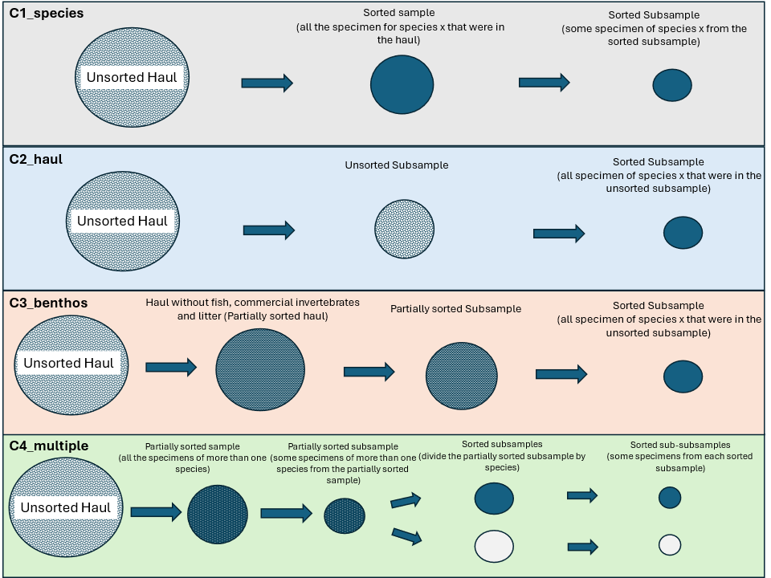

Figure 7: type of subsamples

### Target species

#### **Case 1 (C1_species) - Target species**

ALL individuals collected from the haul (sorted sample), then a subsample is taken (sorted subsample) for individual processing. One record is dedicated to the subsample details. The total weight of the sorted sample (in kilograms) is reported in the in the *kg_field1* field. The weight of the sorted subsample is reported in the *kg_field2*. *type_subsample* is “C1_species”. The individuals subsampled are processed according to the standard procedure for target species, creating a new record for each specimen.

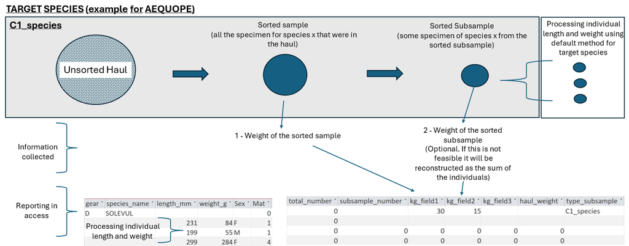

Figure 8: subsamples, case 1 for target species

#### **Case 2 (C2_haul) - Target species**

A subsample is taken from the haul as soon as it is taken (unsorted subsample, before removing anything from the haul), then ALL the individuals in the subsample are collected (sorted subsample) for individual processing. One record is dedicated to the subsample details. The weight of the haul is reported in *haul_weight*. The weigth of the unsorted subsample is reported in *kg_field1*. The weight of the sorted subsample is reported in *kg_field2*. *type_subsample* is “C2_haul”. The individuals subsampled are processed according to the standard procedure for target species, creating a new record for each specimen.

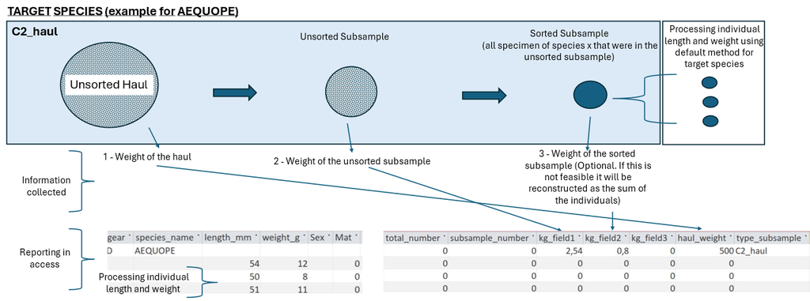

Figure 9: subsamples, case 2 for target species

#### **Case 3 (C3_benthos) - Target species**

A subsample is taken from the haul after partial sorting (partially sorted subsample). This procedure is tipically applied to benthos subsample, which is taken after commercial species and litter are removed. Therefore, subsamples taken with this procedure need to be raised using the standard procedure to raise discard data. Then, ALL the individuals in the subsample are collected (sorted subsample) for individual processing. One record is dedicated to the subsample details. The weight of the haul is reported in *haul_weight*. The weigth of the unsorted subsample is reported in *kg_field1*. The weight of the sorted subsample is reported in *kg_field2*. *type_subsample* is “C3_benthos”. The individuals subsampled are processed according to the standard procedure for target species, creating a new record for each specimen.

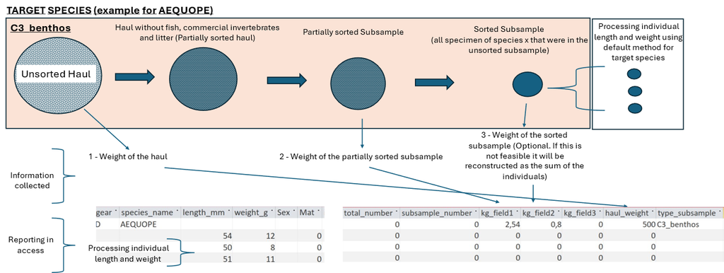

Figure 10: subsamples, case 3 for target species

### Non-target species (MUREBRA, HEXATRU, etc..)

#### **Case 1 (C1_species) - Non target**

ALL individuals collected from the haul (sorted sample), then a subsample is taken (sorted subsample) for estimating total number. One record is dedicated to the subsample details. The total weight of the sorted sample (in kilograms) is reported in the in the *kg_field1* field. The weight of the sorted subsample is reported in the *kg_field2*. The number of individual in the sorted subsample is reported in the *subsample_number*. *type_subsample* is “C1_species”.

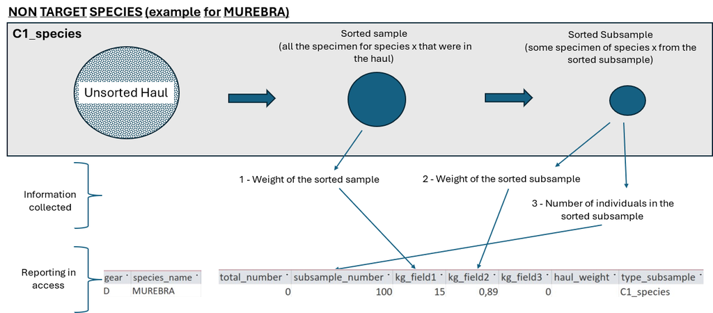

Figure 11: subsamples, case 1 for non target species

#### **Case 2 (C2_haul) - Non target**

A subsample is taken from the haul as soon as it is taken (unsorted subsample, before removing anything from the haul), then ALL the individuals in the subsample are collected (sorted subsample) for estimating total number. One record is dedicated to the subsample details. The weight of the haul is reported in *haul_weight*. The weigth of the unsorted subsample is reported in *kg_field1*. The weight of the sorted subsample is reported in *kg_field2*. The number of individual in the sorted subsample is reported in the *subsample_number*. *type_subsample* is “C2_haul”.

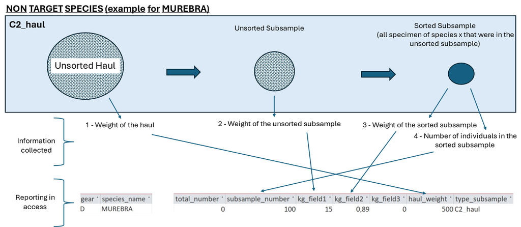

Figure 12: subsamples, case 2 for non target species

#### **Case 3 (C3_benthos) - Non target**

A subsample is taken from the haul after partial sorting (partially sorted subsample). This procedure is tipically applied to benthos subsample, which is taken after commercial species and litter are removed. Therefore, subsamples taken with this procedure need to be raised using the standard procedure to raise discard data. Then, ALL the individuals in the subsample are collected (sorted subsample) for individual processing. One record is dedicated to the subsample details. The weight of the haul is reported in *haul_weight*. The weigth of the unsorted subsample is reported in *kg_field1*. The weight of the sorted subsample is reported in *kg_field2*. The number of individual in the sorted subsample is reported in the *subsample_number*. *type_subsample* is “C3_benthos”.

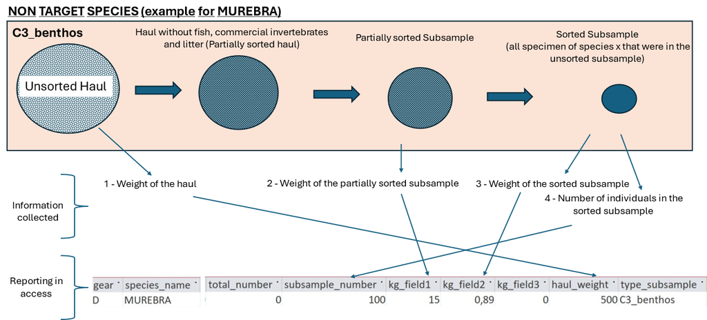

Figure 13: subsamples, case 3 for non target

#### **Case 4 (C4_multiple) - Non target**

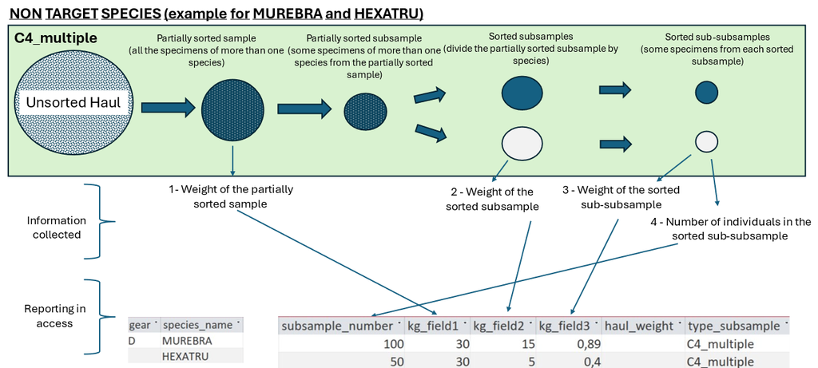

Figure 14: subsamples, case 4 for non target

# Processing data

Data are processed in R. It is good practice to process the data relatively frequently in order to create backup files and to produce some checks that can be used to adjust data.

## process haul data

Data stored in the .accdb file are retrieved and handled by R scripts, located in the “R” folder. The required script is `workflow_access_v2024.R`.

### process single hauls

To process single hauls, run the lines up to 15 and then please set the following parameters:

- **haul**: number of the haul corresponding to the name given in the access file, but without the extension ’‘. Example: ’cala22’ in access is ‘22’ here, ‘cala45bis’ is ‘45bis’
- **db**: suffix given to the acces file. E.g.: if access file name is *‘Maschera inserimento SOLEMON_test.accdb’*, type just *‘test’* here.
- **updateID**: this control if update (‘Y’) or not (‘N’) the serial number ‘fishID’. Recommended to type ‘Y’ only when batch processing all the hauls.
- **area_sepia**: old command
- **year**: year of the survey
- **area**: stratum of the haul

```
# set parameters
haul=22
db='test'
updateID='N'
area_sepia='D'
year=2022
area='ITA17'
```

When parameters are set, the data processing is pre-defined: you just have to run it without changing the parameters. The first step is the `function1`, which scope is to format the access table according to output standards. There is no need to see the output of this function. Just run it.

```
# function1 extract data from access db and format them
hauldata=function1(haul=haul,
                   db=db,
                   year=year)# extract and format data
```

When the function1 is done, you can proceed with the `function2`, which scope is to perform some checks. Checks done are plots that would be saved under the path ‘output/checks’

```
# function 2: perform checks
function2(xdat=hauldata,
          haul=haul)
```

`function3` scope is to format data according to trust format. Excel sheets are saved under the path ‘output/trust’.

```
# function 3: format data to trust format
trustdat=function3(xdat=hauldata[[1]],
                  haul=haul,
                  year = year,
                  weight_not_target = hauldata[[2]],
                  subsamples_target=hauldata[[3]],
                  catch_sample_disattivati = catch_sample_disattivati) # function 2
```

`function4` creates a pdf report and save it under the path ‘output/pdf’.

```
# function4: save PDF
function4(trustdat = trustdat,
          year=year,
          area = area,
          haul=haul)
```

### loop to process more hauls

To process more than one haul, you should care to properly fill in the ‘haul_order’ excel sheet (see input data section). After having loaded the haul summary, just run the loop represented below.

```
haul_summary=read_excel("data/haul_order.xlsx")
haul_summary=haul_summary[1:5,]

for(xhaul in 1:nrow(haul_summary)){


  # loop parameters
  haul=haul_summary[xhaul,]$haul
  db=haul_summary[xhaul,]$DB
  area=haul_summary[xhaul,]$country

  cat('processing haul no.', haul, '(', xhaul,'/', nrow(haul_summary),')' )

  # function1 extract data from access db and format them
  hauldata=function1(haul=haul,
                     db=db,
                     year=year)# extract and format data

  # function 2: perform checks
  function2(xdat=hauldata,
            haul=haul)

  # function 3: format data to trust format
  trustdat=function3(xdat=hauldata[[1]],
                     haul=haul,
                     year = year,
                     weight_not_target = hauldata[[2]],
                     subsamples_target=hauldata[[3]],
                     catch_sample_disattivati = catch_sample_disattivati) # function 2

  # function4: save PDF
  function4(trustdat = trustdat,
            year=year,
            area=area,
            haul=haul)


}
```

# Data files associated to the folder

### target_species

Contains the species that are target for the survey (individual length and weight) and the molluscs for which only total weight and total number are needed.

- **Species**: species solemon code
- **target**: indicates which type of target is the species. 1 is for species that requires individual length and weight; 2 is for molluscs that requires total weight and total number

List of target species. Target = 1 are proper target; Target = 2 are shellfishes on which to collect number and weight

| Species | Species_code | target |
| --- | --- | --- |
| Aequipecten opercularis | AEQUOPE | 1 |
| Callinectes sapidus | CALLSAP | 1 |
| Chlamys glabra | CHLAGLA | 1 |
| Liocarcinus depurator | LIOCDEP | 1 |
| Melicertus kerathurus | MELIKER | 1 |
| Merluccius merluccius | MERLMER | 1 |
| Mullus barbatus | MULLBAR | 1 |
| Nephrops norvegicus | NEPRNOR | 1 |
| Parapenaeus longirostris | PAPELON | 1 |
| Pecten jacobaeus | PECTJAC | 1 |
| Penaeus aztecus | PENAZTC | 1 |
| Platichthys flesus | PLATFLE | 1 |
| Psetta maxima | PSETMAX | 1 |
| Raja asterias | RAJAAST | 1 |
| Raja clavata | RAJACLA | 1 |
| Raja miraletus | RAJAMIR | 1 |
| Scophthalmus rhombus | SCOHRHO | 1 |
| Scyliorhinus canicula | SCYOCAN | 1 |
| Scyliorhinus stellaris | SCYOSTE | 1 |
| Sepia officinalis | SEPIOFF | 1 |
| Solea aegyptiaca | SOLEAEG | 1 |
| Solea solea | SOLEVUL | 1 |
| Squilla mantis | SQUIMAN | 1 |
| Torpedo marmorata | TORPMAR | 1 |
| Crassostrea gigas | CRASGIG | 2 |
| Galeodea echinophora | GALEECH | 2 |
| Hexaplex trunculus | HEXATRU | 2 |
| Bolinus brandaris | MUREBRA | 2 |
| Mytilus galloprovincialis | MYTGALL | 2 |
| Natica stercusmuscarum | NATISTE | 2 |
| Ostrea edulis | OSTREDU | 2 |
| Rapana venosa | RAPAVEN | 2 |

### catch_sample_disattivati

This file controls formatting of trust templates. It indicates which samples (Station, Gear and SpecCode) should be indicated as “InUse” = FALSE in the catch sample files used as input data in trust.

### fishID

Store the *updated* serial number used to identify specimens for which detailed samples (otolit, genetic etc.) were taken. This number should refere to the *last* ID assigned to a specimen. The use of this file is controlled by the `updateID` parameter in the workflow_access_v0 file: if `updateID` is set equal to Y, the fishID file is used to assign IDs (when requested) and it is then updated. The columns refers to:

- **type**: not useful (to be removed)
- **code**: this is the alphanumeric part of the code to be assigned to specimens
- **fishID**: serial number referring to the *last* individual contained in the past records
- **haul**: not useful (to be removed)
- **species**: indicates which species belong to the code category. If need to add species, use : as separator and do not insert spaces.

Example of the fishID file structure

| type | code | fishID | haul | species |
| --- | --- | --- | --- | --- |
| ELAS | Elas | 202 | NA | RAJAAST:RAJACLA:RAJAMIR:TORPMAR |
| solea | SS | 7061 | NA | SOLEVUL:SOLEAEG |
| RHO | SR | 447 | NA | SCOHRHO |

### haul_order

Store the information associated with hauls. This file is used (1) when the data workflow is applied in loop; (2) by the minilog script. The columns refers to:

Example of the haul_order file structure

| day | haul | id | note | inizio | fine | valid | DB | country | peso_rapido_A | peso_rapido_D | peso_subcampione_a | peso_subcampione_b | duration |
| --- | --- | --- | --- | --- | --- | --- | --- | --- | --- | --- | --- | --- | --- |
| 2024-11-06 | 10 | 1 | cavo 135 passi, qualche metro in più al rap A. Giri motore 950 | 1899-12-31 14:40:00 | 1899-12-31 15:10:00 | 1 | NA | ITA | 76 | 60 | 4.4 | NA | 30 |
| 2024-11-09 | 12 | 2 | cavo 90 passi giri motore 920, parte sogliole rapi a misurate a bordo | 1899-12-31 08:10:00 | 1899-12-31 08:40:00 | 1 | NA | ITA | 55 | 50 | 3.1 | NA | 30 |
| 2024-11-09 | 13 | 3 | cavo 150 passi giri motore 920 | 1899-12-31 12:19:00 | 1899-12-31 12:49:00 | 1 | NA | ITA | 40 | 50 | 4.3 | NA | 30 |

### lw_pars

Store the length-weigth parameters of target species. This file is used to reconstruct length (or weight) when it is not available in the recorded data. Example: shrimps where missi a part of the tail but have the head intact are suitable only for length measurement; fishes that were spoiled by the gear may be ok for weight but not measurables for length. The columns refers to:

- **species_name**: indicates which species belong to the code category (solemon code)
- **sex**: indicates the sex in case when sexual dimorphism in the growth is relevant. If dimorphism is not relevant, put combined parameter and write NA in this field
- **a**: parameter “a” for the length-weight relationship
- **b**: parameter “b” for the length-weight relationship
- **source**: source from where a and b were retrieved

Example of the lw_pars file structure

| species_name | sex | a | b | source |
| --- | --- | --- | --- | --- |
| SOLEVUL | NA | 0.00460 | 3.11 | benchmark_assessment |
| MULLBAR | NA | 0.00871 | 3.09 | fishbase |
| RAJACLA | NA | 0.00269 | 3.23 | fishbase |

### maturity_stages

Store the code of the maturity scales for target species. This file is used to format input files for trust.

- **SPECIES**: indicates which species belong to the code category (solemon code)
- **SEX**: indicates the sex
- **SCALE**: include the alphanumeric part of the maturity scale code

Example of the maturity_stages file structure

| SPECIES | SEX | SCALE |
| --- | --- | --- |
| MELIKER | F | MEDPF |
| MERLMER | F | MEDFI |
| MERLMER | M | MEDFI |

### solemon_TB

This is just the TB file updated to 2021, as stored in trust. It serves to perform some checks and it should not be modified. Preview not shown.

### species_list

- **Species**: species scientific name
- **Medits**: species solemon code
- **Sp_Subcat**: commercial category of the species
- **Lan_Class**: not relevant
- **Sp_Subcat**: not relevant

Example of the species_list file structure

| Species | Medits | Sp_Subcat | Len_Class | Notes |
| --- | --- | --- | --- | --- |
| Aaptos aaptos | AAPTAAP | E | NA | NA |
| Abra prismatica | ABRAPRI | E | NA | NA |
| Abra sp | ABRASPP | E | NA | NA |